# Tugas Kelompok 10 Praktikum Pemrograman Statistika

Authors

M0501261009 - Nurhafifah

M0501261051 - Muhammad Al Ghifary

M0501261074 - Khansa Qamila

## Soal 1

**Note**

Diberikan dataset mentah pada tabel berikut:

Dataset Nilai Mahasiswa

| Nama | Matematika | Statistika | Umur |
| --- | --- | --- | --- |
| Andi | 80 | 85 | 21 |
| Budi | 90 | 88 | 20 |
| Citra | NA | 78 | 22 |
| Dewi | 75 | - | 21 |
| Andi | 80 | 85 | 21 |

### Instruksi Pengerjaan:

1. Buat data frame bernama `nilai_raw` secara manual di R berdasarkan tabel di atas.
2. Identifikasi nilai yang hilang pada dataset secara sistematis. Ubah tanda hubung (`"-"`) pada nilai Statistika milik Dewi menjadi nilai hilang standar R, yaitu `NA`.
3. Lakukan imputasi terhadap nilai Statistika yang kosong menggunakan rata-rata nilai Statistika mahasiswa lainnya yang tersedia.
4. Buat kolom baru bernama `Status_Umur` menggunakan fungsi `ifelse()` dengan ketentuan:
   - **Dewasa** jika $\text{Umur} \ge 21$ tahun
   - **Muda** jika $\text{Umur} < 21$ tahun
5. Identifikasi dan hapus baris pengamatan yang duplikat.
6. Simpan dataset yang telah dibersihkan ke dalam file bernama `nilai_bersih.csv`.

### Jawab :

#### 1. Buat data frame bernama `nilai_raw` secara manual di R berdasarkan tabel di atas.

```r
# Membuat Data frame secara manual
nilai_raw <- data.frame(Nama = c("Andi"," Budi","Citra","Dewi", "Andi"),
                Matematika = c("80","90","NA","75","80"),
                Statistika = c("85","88","78","-","85"),
                Umur = c(21,20,22,21,21))
nilai_raw
```

```
   Nama Matematika Statistika Umur
1  Andi         80         85   21
2  Budi         90         88   20
3 Citra         NA         78   22
4  Dewi         75          -   21
5  Andi         80         85   21
```

#### 2. Identifikasi nilai yang hilang dan Ubah tanda hubung (“-”) pada nilai Statistika milik Dewi menjadi NA.

```r
# Identifikasi NA dan ubah tanda hubung ("-") pada nilai Statistika milik Dewi menjadi NA
nilai_raw$Statistika[nilai_raw$Statistika == "-"] <- NA
nilai_raw$Matematika[nilai_raw$Matematika == "NA"] <- NA
nilai_raw
```

```
   Nama Matematika Statistika Umur
1  Andi         80         85   21
2  Budi         90         88   20
3 Citra       <NA>         78   22
4  Dewi         75       <NA>   21
5  Andi         80         85   21
```

```r
#ubah jenis data statistika dan matematik menjadi numerik
nilai_raw$Matematika <- as.numeric(nilai_raw$Matematika)
nilai_raw$Statistika <- as.numeric(nilai_raw$Statistika)
nilai_raw
```

```
   Nama Matematika Statistika Umur
1  Andi         80         85   21
2  Budi         90         88   20
3 Citra         NA         78   22
4  Dewi         75         NA   21
5  Andi         80         85   21
```

#### 3. Lakukan imputasi terhadap nilai Statistika yang kosong menggunakan rata-rata nilai Statistika mahasiswa lainnya yang tersedia.

```r
# Masukkan nilai statistika yang kosong
rata_statistika <- mean(nilai_raw$Statistika, na.rm = TRUE)
nilai_raw$Statistika[is.na(nilai_raw$Statistika)] <- rata_statistika
nilai_raw
```

```
   Nama Matematika Statistika Umur
1  Andi         80         85   21
2  Budi         90         88   20
3 Citra         NA         78   22
4  Dewi         75         84   21
5  Andi         80         85   21
```

#### 4. Buat kolom baru bernama Status_Umur menggunakan fungsi ifelse() dengan ketentuan: Dewasa jika umur ≥ 21 tahun; Muda jika umur < 21 tahun.

```r
# Membuat kolom baru
nilai_raw$Status_Umur <- ifelse(nilai_raw$Umur >= 21, "Dewasa", "Muda")
nilai_raw
```

```
   Nama Matematika Statistika Umur Status_Umur
1  Andi         80         85   21      Dewasa
2  Budi         90         88   20        Muda
3 Citra         NA         78   22      Dewasa
4  Dewi         75         84   21      Dewasa
5  Andi         80         85   21      Dewasa
```

#### 5. Identifikasi dan hapus baris pengamatan yang duplikat.

```r
# Identifikasi baris pengamatan yang duplikat.
duplicated(nilai_raw)
```

```
[1] FALSE FALSE FALSE FALSE  TRUE
```

```r
# Mengambil barisan yang mengandung duplikat
nilai_raw[duplicated(nilai_raw) | duplicated(nilai_raw, fromLast = TRUE), ]
```

```
  Nama Matematika Statistika Umur Status_Umur
1 Andi         80         85   21      Dewasa
5 Andi         80         85   21      Dewasa
```

```r
# Menghapus baris pengamatan yang duplikat
nilai_bersih <- unique(nilai_raw)
nilai_bersih
```

```
   Nama Matematika Statistika Umur Status_Umur
1  Andi         80         85   21      Dewasa
2  Budi         90         88   20        Muda
3 Citra         NA         78   22      Dewasa
4  Dewi         75         84   21      Dewasa
```

#### 6. Simpan dataset yang telah dibersihkan ke dalam file bernama `nilai_bersih.csv`

```r
# Menyimpan data ke file csv
write.csv(nilai_bersih, "nilai_bersih.csv", row.names = FALSE)
```

## Soal 2

**Note**

Gunakan dataset profil pada Tabel 2 berikut.

Tabel 2. Dataset Profil

| **No** | **Gender** | **V1** | **V2** | **V3** | **V4** | **V5** | **V6** | **V7** | **V8** | **V9** | **V10** |
| --- | --- | --- | --- | --- | --- | --- | --- | --- | --- | --- | --- |
| **1** | F | 8 | 9 | 5 | 9 | 9 | 9 | 5 | 9 | 11 | 8 |
| **2** | F | 15 | 8 | 9 | 5 | 10 | 8 | 10 | 12 | 9 | 15 |
| **3** | F | 8 | 13 | 12 | 6 | 7 | 9 | 14 | 12 | 12 | 9 |
| **4** | M | 14 | 9 | 8 | NA | 11 | 10 | 6 | 11 | 11 | 8 |
| **5** | M | 8 | 2 | 9 | 16 | 8 | 10 | 8 | 9 | 8 | 9 |
| **6** | F | 10 | 6 | 10 | 9 | 10 | 10 | 9 | 7 | 7 | 11 |
| **7** | M | 9 | 9 | 7 | 13 | 9 | 12 | 10 | 9 | 11 | 7 |
| **8** | M | 9 | 10 | 8 | 10 | 5 | 10 | 6 | 12 | 6 | 8 |
| **9** | F | 10 | 13 | 6 | 7 | 10 | 12 | 13 | 9 | 6 | 9 |
| **10** | M | 12 | 10 | 9 | 8 | 17 | 7 | 9 | 10 | 7 | 7 |

### Lakukan tahapan berikut.

1. Buat data frame bernama profil secara manual di R berdasarkan Tabel 2.
2. Lakukan penyaringan (subsetting) sehingga hanya menyisakan pengamatan yang memenuhi salah satu kondisi berikut: gender laki-laki (m) dan v1 > 9 ; atau gender perempuan (f) dan v3 <= 10.
3. Urutkan data hasil penyaringan secara multikriteria, dengan ketentuan: gender diurutkan secara descending; untuk pengamatan dengan gender yang sama, v5 diurutkan secara ascending.
4. Simpan hasil akhir ke dalam file bernama profil_filter.csv.

### Jawab :

#### 1. Buat data frame bernama profil secara manual di R berdasarkan Tabel 2.

```r
# Langkah 1: Membuat Data Frame Profil
profil <- data.frame(
  No     = 1:10,
  gender = c("f", "f", "f", "m", "m", "f", "m", "m", "f", "m"),
  v1     = c(8, 15, 8, 14, 8, 10, 9, 9, 10, 12),
  v2     = c(9, 8, 13, 9, 2, 6, 9, 10, 13, 10),
  v3     = c(5, 9, 12, 8, 9, 10, 7, 8, 6, 9),
  v4     = c(9, 5, 6, NA, 16, 9, 13, 10, 7, 8),
  v5     = c(9, 10, 7, 11, 8, 10, 9, 5, 10, 17),
  v6     = c(9, 8, 9, 10, 10, 10, 12, 10, 12, 7),
  v7     = c(5, 10, 14, 6, 8, 9, 10, 6, 13, 9),
  v8     = c(9, 12, 12, 11, 9, 7, 9, 12, 9, 10),
  v9     = c(11, 9, 12, 11, 8, 7, 11, 6, 6, 7),
  v10    = c(8, 15, 9, 8, 9, 11, 7, 8, 9, 7)
)

# Menampilkan data frame profil
profil
```

```
   No gender v1 v2 v3 v4 v5 v6 v7 v8 v9 v10
1   1      f  8  9  5  9  9  9  5  9 11   8
2   2      f 15  8  9  5 10  8 10 12  9  15
3   3      f  8 13 12  6  7  9 14 12 12   9
4   4      m 14  9  8 NA 11 10  6 11 11   8
5   5      m  8  2  9 16  8 10  8  9  8   9
6   6      f 10  6 10  9 10 10  9  7  7  11
7   7      m  9  9  7 13  9 12 10  9 11   7
8   8      m  9 10  8 10  5 10  6 12  6   8
9   9      f 10 13  6  7 10 12 13  9  6   9
10 10      m 12 10  9  8 17  7  9 10  7   7
```

#### 2. Lakukan penyaringan (subsetting) sehingga hanya menyisakan pengamatan yang memenuhi salah satu kondisi berikut: gender laki-laki (m) dan v1 > 9 ; atau gender perempuan (f) dan v3 <= 10.

```r
# Langkah 2: Subsetting Data
profil_subset <- subset(profil, (gender == "m" & v1 > 9) | (gender == "f" & v3 <= 10))

# Menampilkan hasil subsetting
profil_subset
```

```
   No gender v1 v2 v3 v4 v5 v6 v7 v8 v9 v10
1   1      f  8  9  5  9  9  9  5  9 11   8
2   2      f 15  8  9  5 10  8 10 12  9  15
4   4      m 14  9  8 NA 11 10  6 11 11   8
6   6      f 10  6 10  9 10 10  9  7  7  11
9   9      f 10 13  6  7 10 12 13  9  6   9
10 10      m 12 10  9  8 17  7  9 10  7   7
```

#### 3. Urutkan data hasil penyaringan secara multikriteria, dengan ketentuan: gender diurutkan secara descending; untuk pengamatan dengan gender yang sama, v5 diurutkan secara ascending.

```r
# Langkah 3: Pengurutan Multikriteria
profil_sorted <- profil_subset[order(-xtfrm(profil_subset$gender), profil_subset$v5), ]

# Menampilkan hasil setelah diurutkan
profil_sorted
```

```
   No gender v1 v2 v3 v4 v5 v6 v7 v8 v9 v10
4   4      m 14  9  8 NA 11 10  6 11 11   8
10 10      m 12 10  9  8 17  7  9 10  7   7
1   1      f  8  9  5  9  9  9  5  9 11   8
2   2      f 15  8  9  5 10  8 10 12  9  15
6   6      f 10  6 10  9 10 10  9  7  7  11
9   9      f 10 13  6  7 10 12 13  9  6   9
```

#### 4. Simpan hasil akhir ke dalam file bernama profil_filter.csv.

```r
# Langkah 4: Menyimpan Hasil Akhir ke File CSV
write.csv(profil_sorted, file = "profil_filter.csv", row.names = FALSE)
```

## Soal 3

**Note**

Penggabungan dan Reshaping Data Diberikan dua data frame mengenai skor penjualan mingguan beberapa toko berikut:

Diberikan dua data frame mengenai skor penjualan mingguan beberapa toko:

### Lakukan tahapan berikut:

1. Gabungkan df_sales dan df_info menggunakan fungsi merge() dengan metode Full Outer Join, sehingga seluruh toko dari kedua data frame tetap disertakan. Perhatikan bahwa nama variabel kunci pada kedua data frame berbeda, yaitu id_toko pada df_sales dan id pada df_info. Gunakan argumen penggabungan yang sesuai.
2. Ubah struktur data hasil penggabungan dari format Wide menjadi Long, sehingga: Minggu1 dan Minggu2 digabung menjadi satu kolom bernama Waktu; Nilai penjualan disimpan dalam satu kolom bernama Penjualan.
3. Simpan dataset dalam format Long tersebut ke dalam file bernama penjualan_long.csv.

Diberikan dua data frame mengenai skor penjualan mingguan beberapa toko berikut.

```r
df_sales <- data.frame(
  id_toko = c("T1", "T2", "T3"),
  Minggu1 = c(120, 150, 95),
  Minggu2 = c(135, 140, 110) )
df_info <- data.frame(
  id = c("T1", "T2", "T4"),
  Kota = c("Jakarta", "Bandung", "Surabaya") )
df_sales
```

```
  id_toko Minggu1 Minggu2
1      T1     120     135
2      T2     150     140
3      T3      95     110
```

```r
df_info
```

```
  id     Kota
1 T1  Jakarta
2 T2  Bandung
3 T4 Surabaya
```

#### 1. Gabungkan df_sales dan df_info menggunakan fungsi merge() dengan metode Full Outer Join, sehingga seluruh toko dari kedua data frame tetap disertakan. Perhatikan bahwa nama variabel kunci pada kedua data frame berbeda, yaitu id_toko pada df_sales dan id pada df_info. Gunakan argumen penggabungan yang sesuai.

```r
df_gabung <- merge(
  df_sales,
  df_info,
  by.x = "id_toko",
  by.y = "id",
  all = TRUE )
df_gabung
```

```
  id_toko Minggu1 Minggu2     Kota
1      T1     120     135  Jakarta
2      T2     150     140  Bandung
3      T3      95     110     <NA>
4      T4      NA      NA Surabaya
```

#### 2. Ubah struktur data hasil penggabungan dari format Wide menjadi Long, sehingga: Minggu1 dan Minggu2 digabung menjadi satu kolom bernama Waktu; Nilai penjualan disimpan dalam satu kolom bernama Penjualan.

```r
data_long <- reshape(
  df_gabung,
  varying = c("Minggu1", "Minggu2"),
  v.names = "Penjualan",
  timevar = "Waktu",
  times = c("Minggu1", "Minggu2"),
  idvar = c("id_toko"),
  direction = "long"
)
row.names(data_long) <- NULL
data_long
```

```
  id_toko     Kota   Waktu Penjualan
1      T1  Jakarta Minggu1       120
2      T2  Bandung Minggu1       150
3      T3     <NA> Minggu1        95
4      T4 Surabaya Minggu1        NA
5      T1  Jakarta Minggu2       135
6      T2  Bandung Minggu2       140
7      T3     <NA> Minggu2       110
8      T4 Surabaya Minggu2        NA
```

#### 4. Simpan dataset dalam format Long tersebut ke dalam file bernama penjualan_long.csv.

```r
write.csv(data_long,"penjualan_long.csv", row.names = FALSE)
```

## Soal 4

**Note**

Eksplorasi Visual: Gunakan dataset bawaan R `CO2` untuk mengeksplorasi hubungan antara konsentrasi karbon dioksida (`conc`) dan tingkat penyerapan karbon dioksida (`uptake`) pada tanaman.

### Instruksi Pengerjaan:

1. Kenali struktur dataset `CO2` dan identifikasi peran peubah `Plant`, `Type`, `Treatment`, `conc`, dan `uptake`.
2. Buat grafik menggunakan **base R** untuk menunjukkan hubungan `conc` dan `uptake` dengan ketentuan:
   - Mengatur bentuk (`pch`) dan ukuran titik (`cex`);
   - Mengatur warna (`col`), judul (`main`), label sumbu (`xlab` dan `ylab`), serta rentang sumbu (`xlim` dan `ylim`);
   - Menambahkan minimal **dua elemen grafik** menggunakan `points()`, `lines()`, `abline()`, atau `text()`.
3. Buat visualisasi yang sama menggunakan **`ggplot2`** dengan memanfaatkan setidaknya **lima komponen Utama**:
   - `geom_*`
   - `aes`
   - `stat_*`
   - `scale_*`
   - `facet_*` atau `coord_*`
4. Berikan kustomisasi tambahan pada grafik `ggplot2` menggunakan `theme()` agar tampilan grafik lebih informatif dan menarik.
5. Simpan grafik hasil `ggplot2` ke dalam file gambar bernama `co2_uptake_visualisasi.png` menggunakan fungsi `ggsave()`.

### Jawab:

#### 1. Kenali struktur dataset CO2 dan identifikasi peran peubah Plant, Type, Treatment, conc, dan uptake, kemudian buat grafik menggunakan base R untuk menunjukkan hubungan conc dan uptake dengan mengatur bentuk dan ukuran titik, warna, judul, label sumbu, serta rentang sumbu, lalu tambahkan minimal dua elemen grafik menggunakan points(), lines(), abline(), atau text().

```r
# Mengenali struktur dataset CO2
str(CO2)
```

```
Classes 'nfnGroupedData', 'nfGroupedData', 'groupedData' and 'data.frame':  84 obs. of  5 variables:
 $ Plant    : Ord.factor w/ 12 levels "Qn1"<"Qn2"<"Qn3"<..: 1 1 1 1 1 1 1 2 2 2 ...
 $ Type     : Factor w/ 2 levels "Quebec","Mississippi": 1 1 1 1 1 1 1 1 1 1 ...
 $ Treatment: Factor w/ 2 levels "nonchilled","chilled": 1 1 1 1 1 1 1 1 1 1 ...
 $ conc     : num  95 175 250 350 500 675 1000 95 175 250 ...
 $ uptake   : num  16 30.4 34.8 37.2 35.3 39.2 39.7 13.6 27.3 37.1 ...
 - attr(*, "formula")=Class 'formula'  language uptake ~ conc | Plant
  .. ..- attr(*, ".Environment")=<environment: R_EmptyEnv>
 - attr(*, "outer")=Class 'formula'  language ~Treatment * Type
  .. ..- attr(*, ".Environment")=<environment: R_EmptyEnv>
 - attr(*, "labels")=List of 2
  ..$ x: chr "Ambient carbon dioxide concentration"
  ..$ y: chr "CO2 uptake rate"
 - attr(*, "units")=List of 2
  ..$ x: chr "(uL/L)"
  ..$ y: chr "(umol/m^2 s)"
```

```r
head(CO2)
```

```
  Plant   Type  Treatment conc uptake
1   Qn1 Quebec nonchilled   95   16.0
2   Qn1 Quebec nonchilled  175   30.4
3   Qn1 Quebec nonchilled  250   34.8
4   Qn1 Quebec nonchilled  350   37.2
5   Qn1 Quebec nonchilled  500   35.3
6   Qn1 Quebec nonchilled  675   39.2
```

```r
min(CO2$conc)
```

```
[1] 95
```

```r
max(CO2$conc)
```

```
[1] 1000
```

```r
min(CO2$uptake)
```

```
[1] 7.7
```

```r
max(CO2$uptake)
```

```
[1] 45.5
```

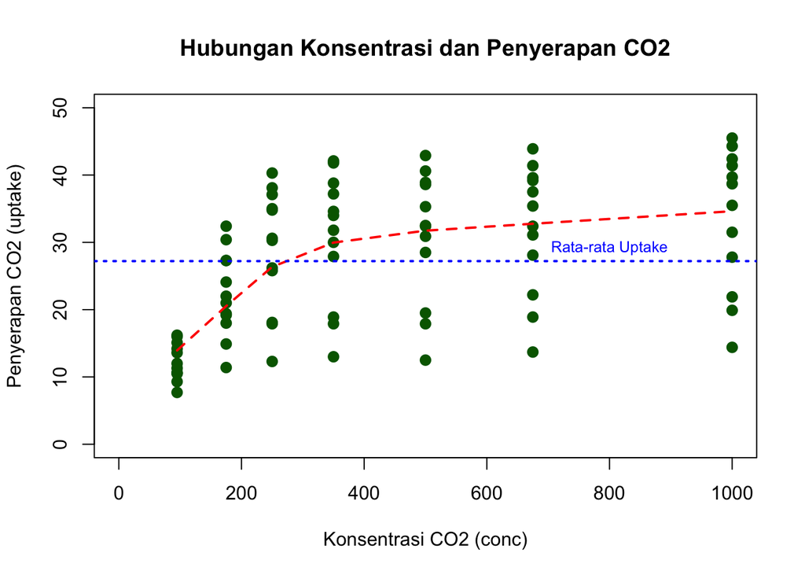

```r
# Identifikasi peran peubah:
# - Plant    : Categorical (Ordered Factor) -> Identitas individu tanaman
# - Type     : Categorical (Factor)         -> Asal tanaman (Quebec / Mississippi)
# - Treatment: Categorical (Factor)         -> Perlakuan (nonchilled / chilled)
# - conc     : Numerik (Kuantitatif)       -> Konsentrasi CO2 (ppm) [Peubah Bebas/X]
# - uptake   : Numerik (Kuantitatif)       -> Tingkat penyerapan CO2 (umol/m^2 sec) [Peubah Terikat/Y]

# Scatter plot menggunakan Base R
plot(CO2$conc, CO2$uptake,
     main = "Hubungan Konsentrasi dan Penyerapan CO2",
     xlab = "Konsentrasi CO2 (conc)",
     ylab = "Penyerapan CO2 (uptake)",
     xlim = c(0, 1000),
     ylim = c(0, 50),
     pch = 19,
     col = "darkgreen",
     cex = 1.2)

# Elemen Tambahan 1: Garis tren (lines)
lines(lowess(CO2$conc, CO2$uptake), col = "red", lwd = 2, lty = 2)

# Elemen Tambahan 2: Garis rata-rata penyerapan (abline)
abline(h = mean(CO2$uptake), col = "blue", lty = 3, lwd = 2)

# Elemen Tambahan 3: Catatan teks pada grafik (text)
text(x = 800, y = mean(CO2$uptake) + 2, labels = "Rata-rata Uptake", col = "blue", cex = 0.8)
```

**Note**

#### 2. Buat satu tampilan grafik berukuran 2 × 2 yang terdiri atas empat jenis visualisasi berbeda untuk mengeksplorasi conc, uptake, Type, dan Treatment; tentukan sendiri jenis grafik yang paling sesuai dan berikan judul yang jelas pada setiap grafik.

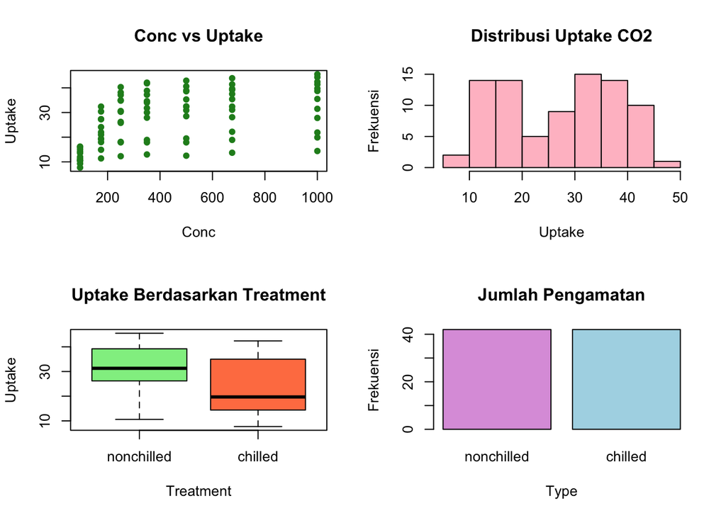

```r
# Mengatur layout 2x2
par(mfrow = c(2, 2))

# Grafik 1: Scatter plot conc vs uptake
plot(CO2$conc, CO2$uptake, col = "forestgreen", pch = 16,
     main = "Conc vs Uptake", xlab = "Conc", ylab = "Uptake")

# Grafik 2: Histogram distribusi uptake
hist(CO2$uptake, col = "pink",
     main = "Distribusi Uptake CO2",
     xlab = "Uptake", ylab = "Frekuensi")

# Grafik 3: Boxplot uptake berdasarkan Treatment
boxplot(uptake ~ Treatment, data = CO2, col = c("lightgreen", "coral"),
        main = "Uptake Berdasarkan Treatment", xlab = "Treatment", ylab = "Uptake")

# Grafik 4: Barplot distribusi jumlah data berdasarkan Type & Treatment
counts <- table(CO2$Treatment)
barplot(counts, beside = TRUE, col = c("plum", "lightblue"),
        main = "Jumlah Pengamatan", xlab = "Type", ylab = "Frekuensi")
```

```r
# Mengembalikan layout ke semula
par(mfrow = c(1, 1))
```

#### 3. Gunakan qplot() untuk membuat visualisasi cepat hubungan conc dan uptake berdasarkan Treatment, kemudian buat kembali visualisasi tersebut menggunakan ggplot2 dengan memetakan Treatment dan Type ke atribut visual yang berbeda di dalam aes() serta menggunakan geom_* yang sesuai.

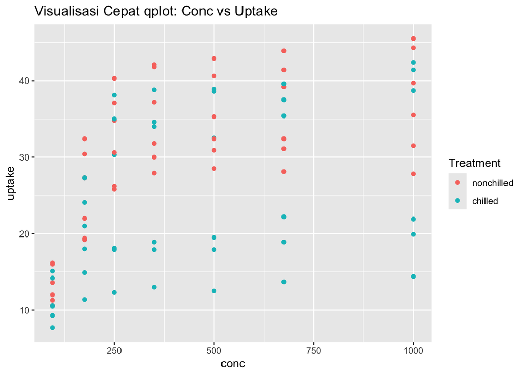

```r
library(ggplot2)

# Visualisasi cepat menggunakan qplot()
qplot(conc, uptake, data = CO2, color = Treatment,
      main = "Visualisasi Cepat qplot: Conc vs Uptake")
```

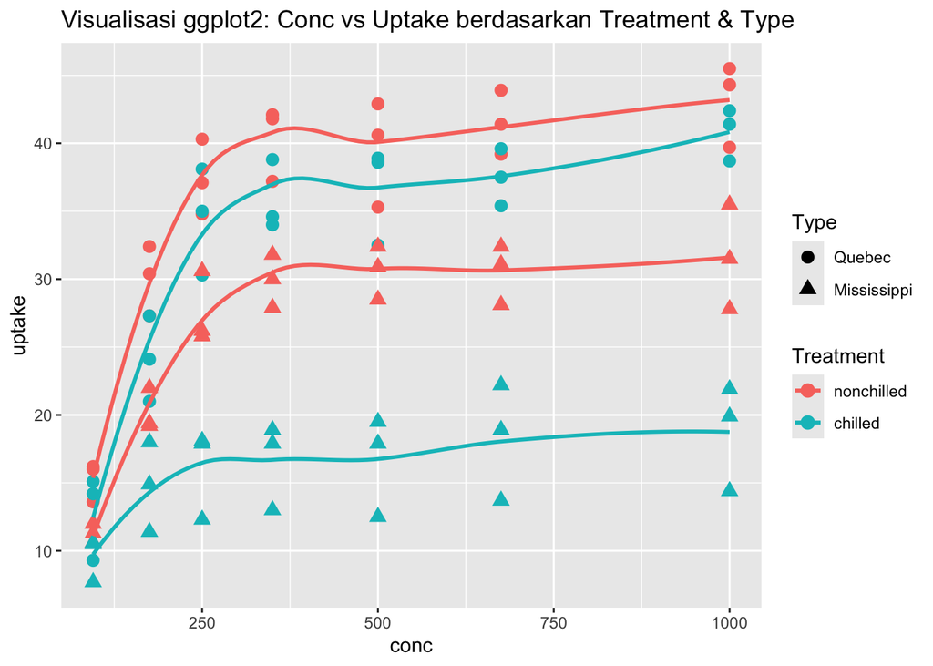

```r
# Visualisasi menggunakan ggplot2 (Treatment & Type ke atribut visual berbeda)
ggplot(CO2, aes(x = conc, y = uptake, color = Treatment, shape = Type)) +
  geom_point(size = 3) +
  geom_smooth(method = "loess", se = FALSE) +
  labs(title = "Visualisasi ggplot2: Conc vs Uptake berdasarkan Treatment & Type")
```

#### 4. Kembangkan grafik ggplot2 tersebut dengan menambahkan minimal satu stat_*, satu scale_*, serta salah satu coord_*, kemudian lengkapi grafik menggunakan labs() dan theme() atau salah satu tema siap pakai agar grafik lebih informatif dan mudah dibaca.

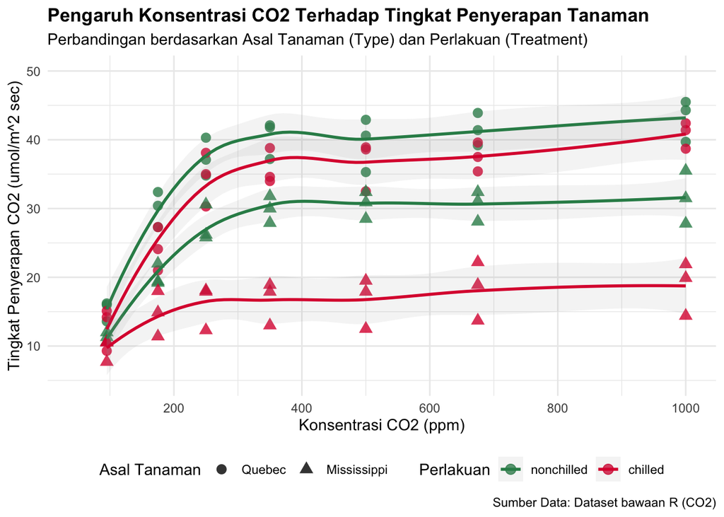

```r
library(ggplot2)

ggplot(CO2, aes(x = conc, y = uptake, color = Treatment, shape = Type)) +
  # geom_* : Point dan Line
  geom_point(size = 3, alpha = 0.8) +
  # stat_* : Stat smooth (garis regresi/tren)
  stat_smooth(method = "loess", se = TRUE, alpha = 0.1) +
  # scale_* : Custom skala warna dan format sumbu
  scale_color_manual(values = c("nonchilled" = "#2E8B57", "chilled" = "#DC143C")) +
  scale_x_continuous(breaks = seq(0, 1000, by = 200)) +
  # coord_* : Membatasi tampilan koordinat sumbu
  coord_cartesian(xlim = c(50, 1000), ylim = c(5, 50)) +
  # labs() : Label komprehensif
  labs(
    title = "Pengaruh Konsentrasi CO2 Terhadap Tingkat Penyerapan Tanaman",
    subtitle = "Perbandingan berdasarkan Asal Tanaman (Type) dan Perlakuan (Treatment)",
    x = "Konsentrasi CO2 (ppm)",
    y = "Tingkat Penyerapan CO2 (umol/m^2 sec)",
    color = "Perlakuan",
    shape = "Asal Tanaman",
    caption = "Sumber Data: Dataset bawaan R (CO2)"
  ) +
  # theme() / Tema siap pakai
  theme_minimal() +
  theme(
    plot.title = element_text(face = "bold", size = 13),
    legend.position = "bottom"
  )
```

#### 5. Simpan grafik akhir menggunakan ggsave() dalam format PNG dengan nama co2_uptake_visualisasi.png, kemudian tuliskan interpretasi mengenai hubungan antara konsentrasi CO₂ dan uptake serta perbedaan pola yang terlihat berdasarkan Type dan Treatment.

```r
# Simpan grafik terakhir dari poin 4 ke format PNG
ggsave("co2_uptake_visualisasi.png", width = 8, height = 6, dpi = 300)
```

**Note**

**Kesimpulannya**: Berdasarkan grafik, konsentrasi CO₂ (conc) cenderung meningkatkan tingkat penyerapan CO₂ (uptake), meskipun peningkatannya mulai melambat pada konsentrasi tinggi. Perbedaan asal tanaman dan perlakuan terlihat dari bentuk dan warna titik. Tanaman *Quebec* (lingkaran) dan *Mississippi* (segitiga) menunjukkan pola penyerapan yang berbeda, dengan perlakuan *nonchilled* secara umum memiliki tingkat penyerapan lebih tinggi dibandingkan chilled. Dengan demikian, asal tanaman (Type) dan perlakuan (Treatment) menunjukkan perbedaan terhadap tingkat penyerapan CO₂.